# Analysis of Spatial & Temporal Data

Frequentist Statistical Inference & Statistical Testing (Practice)

22BA13260 - Tran Huy Quan

2026-02-02

# 1 Data preparation

For this practice, we will use the **Palmer Penguins** dataset, which is a popular alternative to the Iris dataset. It contains size measurements for three penguin species on three islands in the Palmer Archipelago, Antarctica.

> **Note:** This analysis follows the structure of “Practices 1-5” but applies the concepts to a biological dataset suitable for both discrete and continuous probability distribution analysis.

## 1.1 Loading Packages

```r
library(tidyverse)
library(gridExtra)
library(MASS)
library(ggridges)
library(viridis)
# We will use the palmerpenguins package for the dataset
# install.packages("palmerpenguins")
library(palmerpenguins)
library(reshape2) # For melt function in correlation plot
```

## 1.2 Loading Data

We load the `penguins` dataset and perform some initial inspection.

```r
data("penguins")
# Remove NAs for cleaner analysis
dat.0 <- penguins %>% drop_na()

head(dat.0)
```

```
## # A tibble: 6 × 8
##   species island    bill_length_mm bill_depth_mm flipper_length_mm body_mass_g
##   <fct>   <fct>              <dbl>         <dbl>             <int>       <int>
## 1 Adelie  Torgersen           39.1          18.7               181        3750
## 2 Adelie  Torgersen           39.5          17.4               186        3800
## 3 Adelie  Torgersen           40.3          18                 195        3250
## 4 Adelie  Torgersen           36.7          19.3               193        3450
## 5 Adelie  Torgersen           39.3          20.6               190        3650
## 6 Adelie  Torgersen           38.9          17.8               181        3625
## # ℹ 2 more variables: sex <fct>, year <int>
```

## 1.3 Initial Visualization

Let’s reshape the data to visualize the distributions of numerical variables, similar to the original practice’s approach.

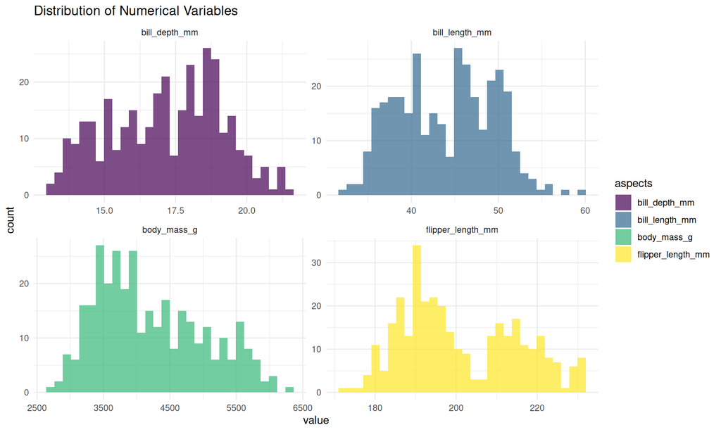

```r
# Extract number-type columns and plot histogram
dat.0.num = dat.0 %>%
  dplyr::select(bill_length_mm, bill_depth_mm, flipper_length_mm, body_mass_g) %>%
  pivot_longer(cols = everything(),
               names_to = "aspects", values_to = "value")

dat.0.num %>% ggplot() +
  geom_histogram(aes(x=value, fill=aspects), bins=30, alpha=0.7) +
  facet_wrap(. ~ aspects, scales="free") +
  theme_minimal() +
  scale_fill_viridis_d() +
  labs(title = "Distribution of Numerical Variables")
```

# 2 Analysis

## 2.1 ED & EDA

> Brief look at the `summary` of the data

```r
summary(dat.0)
```

```
##       species          island    bill_length_mm  bill_depth_mm
##  Adelie   :146   Biscoe   :163   Min.   :32.10   Min.   :13.10
##  Chinstrap: 68   Dream    :123   1st Qu.:39.50   1st Qu.:15.60
##  Gentoo   :119   Torgersen: 47   Median :44.50   Median :17.30
##                                  Mean   :43.99   Mean   :17.16
##                                  3rd Qu.:48.60   3rd Qu.:18.70
##                                  Max.   :59.60   Max.   :21.50
##  flipper_length_mm  body_mass_g       sex           year
##  Min.   :172       Min.   :2700   female:165   Min.   :2007
##  1st Qu.:190       1st Qu.:3550   male  :168   1st Qu.:2007
##  Median :197       Median :4050                Median :2008
##  Mean   :201       Mean   :4207                Mean   :2008
##  3rd Qu.:213       3rd Qu.:4775                3rd Qu.:2009
##  Max.   :231       Max.   :6300                Max.   :2009
```

We can see we have three species (Adelie, Chinstrap, Gentoo) and variables relating to their physical dominance (flipper length, body mass) and beak dimensions (bill length, depth).

Let’s visualize the relationship between **Flipper Length** and **Body Mass**, colored by **Species**.

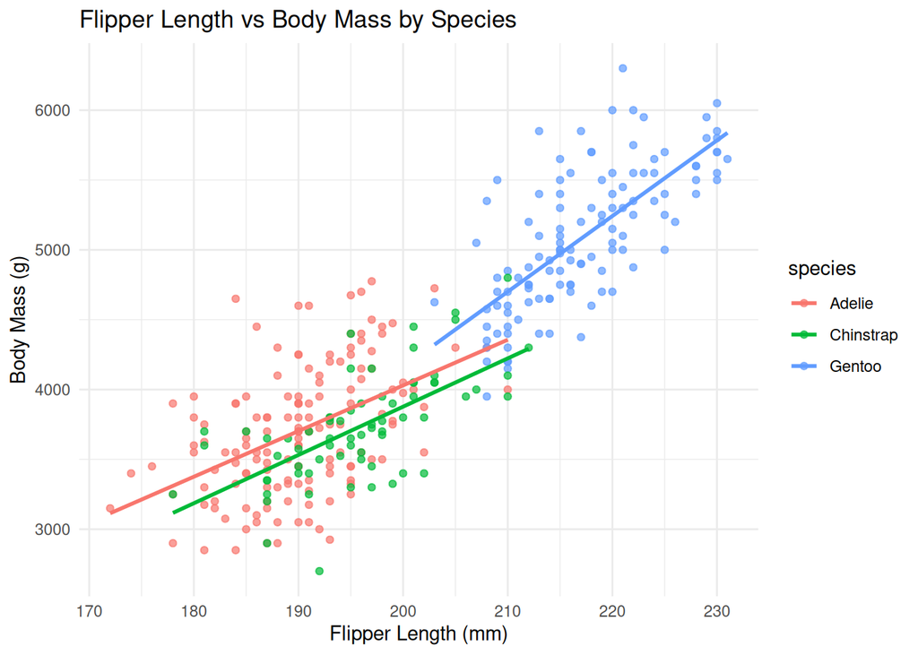

```r
ggplot(dat.0, aes(x = flipper_length_mm, y = body_mass_g, color = species)) +
  geom_point(alpha = 0.7) +
  geom_smooth(method = "lm", se = FALSE) +
  theme_minimal() +
  labs(title = "Flipper Length vs Body Mass by Species",
       x = "Flipper Length (mm)",
       y = "Body Mass (g)")
```

## 2.2 Correlation Analysis

We examine the relationships between the four numerical variables using a correlation matrix.

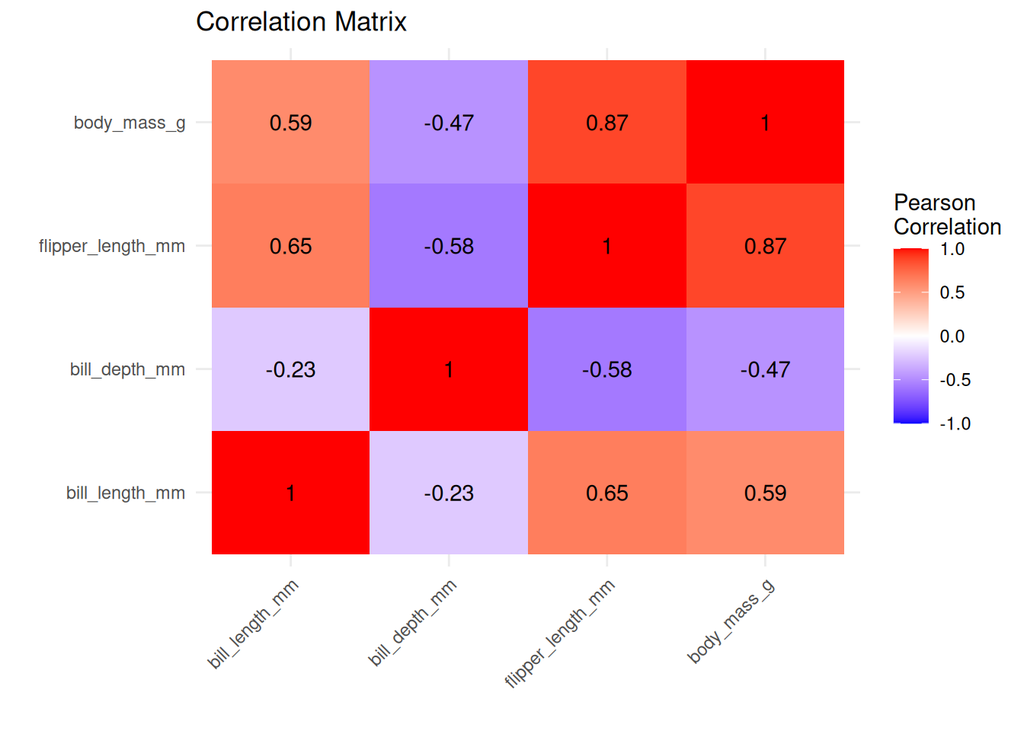

```r
# Calculate correlation matrix
cor_matrix <- dat.0 %>%
  dplyr::select(bill_length_mm, bill_depth_mm, flipper_length_mm, body_mass_g) %>%
  cor()

# Visualize
ggplot(melt(cor_matrix), aes(Var1, Var2, fill = value)) +
  geom_tile() +
  scale_fill_gradient2(low = "blue", high = "red", mid = "white",
                       midpoint = 0, limit = c(-1,1), space = "Lab",
                       name="Pearson\nCorrelation") +
  geom_text(aes(label = round(value, 2)), color = "black") +
  theme_minimal() +
  labs(title = "Correlation Matrix", x = "", y = "") +
  theme(axis.text.x = element_text(angle = 45, vjust = 1, hjust = 1))
```

*Observation:* Flipper length and Body mass are strongly positively correlated ($r > 0.8$). Bill depth is negatively correlated with Flipper length overall (-0.58).

# 3 Parametric Prob. Dist.

## 3.1 Discrete

Let’s look at the discrete distribution of the **Species** variable. This follows a Categorical (Multinoulli) distribution.

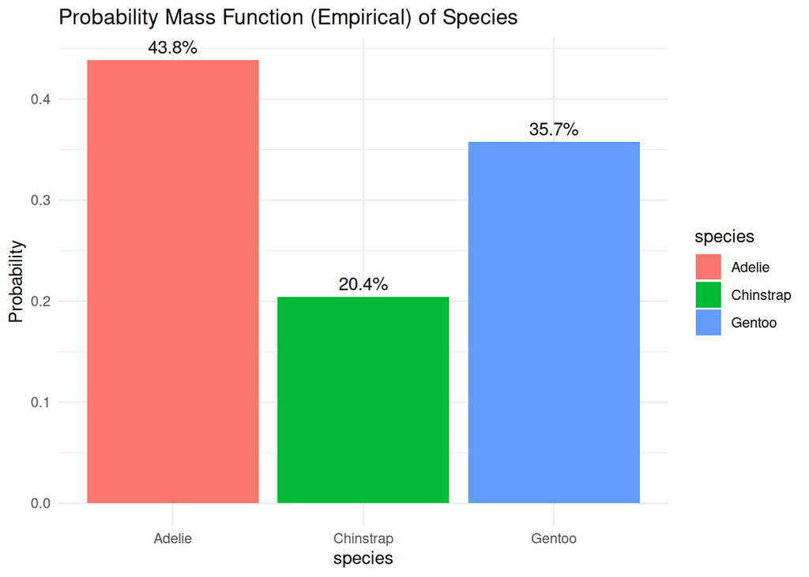

```r
species_counts <- dat.0 %>%
  count(species) %>%
  mutate(prop = n / sum(n))

ggplot(species_counts, aes(x = species, y = prop, fill = species)) +
  geom_col() +
  geom_text(aes(label = scales::percent(prop)), vjust = -0.5) +
  theme_minimal() +
  labs(title = "Probability Mass Function (Empirical) of Species",
       y = "Probability")
```

## 3.2 Continuous

We will model the **Body Mass** of the **Gentoo** penguins using a Normal Distribution. First, we filter the data.

```r
gentoo_mass <- dat.0 %>%
  filter(species == "Gentoo") %>%
  pull(body_mass_g)

# Fit Normal Distribution
fit <- fitdistr(gentoo_mass, "normal")
mean_est <- fit$estimate["mean"]
sd_est <- fit$estimate["sd"]

cat("Estimated Mean:", mean_est, "\nEstimated SD:", sd_est)
```

```
## Estimated Mean: 5092.437
## Estimated SD: 499.3647
```

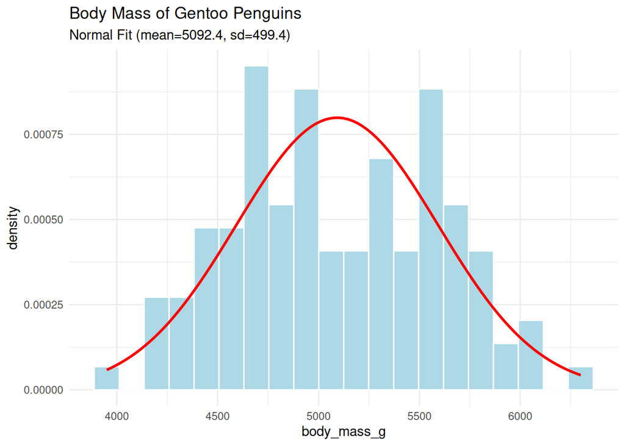

```r
# Plot Histogram with Fitted Density
ggplot(data.frame(body_mass_g = gentoo_mass), aes(x = body_mass_g)) +
  geom_histogram(aes(y = ..density..), bins = 20, fill = "lightblue", color = "white") +
  stat_function(fun = dnorm, args = list(mean = mean_est, sd = sd_est),
                color = "red", size = 1) +
  theme_minimal() +
  labs(title = "Body Mass of Gentoo Penguins",
       subtitle = paste0("Normal Fit (mean=", round(mean_est,1), ", sd=", round(sd_est,1), ")"))
```

## 3.3 Multivariate

Let’s explore the Bivariate Normal distribution approximation for **Bill Length** and **Bill Depth** for **Adelie** penguins.

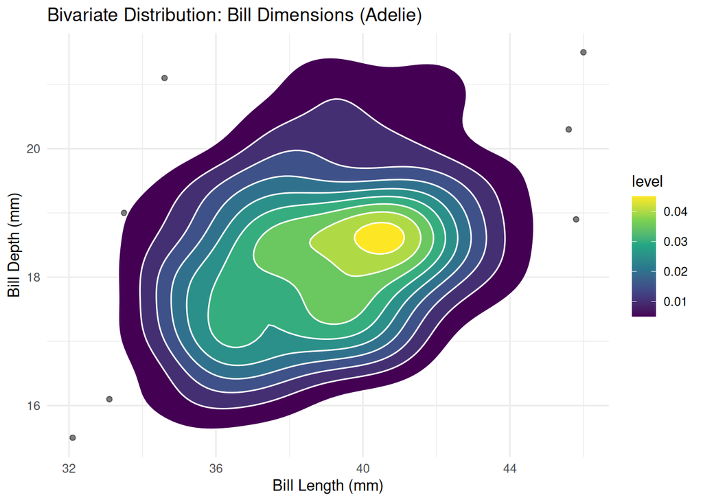

```r
adelie_bill <- dat.0 %>%
  filter(species == "Adelie") %>%
  dplyr::select(bill_length_mm, bill_depth_mm)

ggplot(adelie_bill, aes(x = bill_length_mm, y = bill_depth_mm)) +
  geom_point(alpha=0.5) +
  stat_density_2d(aes(fill = ..level..), geom = "polygon", color="white") +
  scale_fill_viridis_c() +
  theme_minimal() +
  labs(title = "Bivariate Distribution: Bill Dimensions (Adelie)",
       x = "Bill Length (mm)", y = "Bill Depth (mm)")
```

# 4 Frequentist & Testing

We want to test if there is a significant difference in **Body Mass** between **male** and **female** penguins (across all species).

**Hypothesis:**
$$H_0:
\mu_{male} = \mu_{female}$$
$$H_1:
\mu_{male} \neq \mu_{female}$$

We will use a t-test (or Welch’s t-test), but first, we must check assumptions.

## 4.1 Assumption 1 & Results

**Assumption: Normality.** The data distributions for each group should be approximately normal.

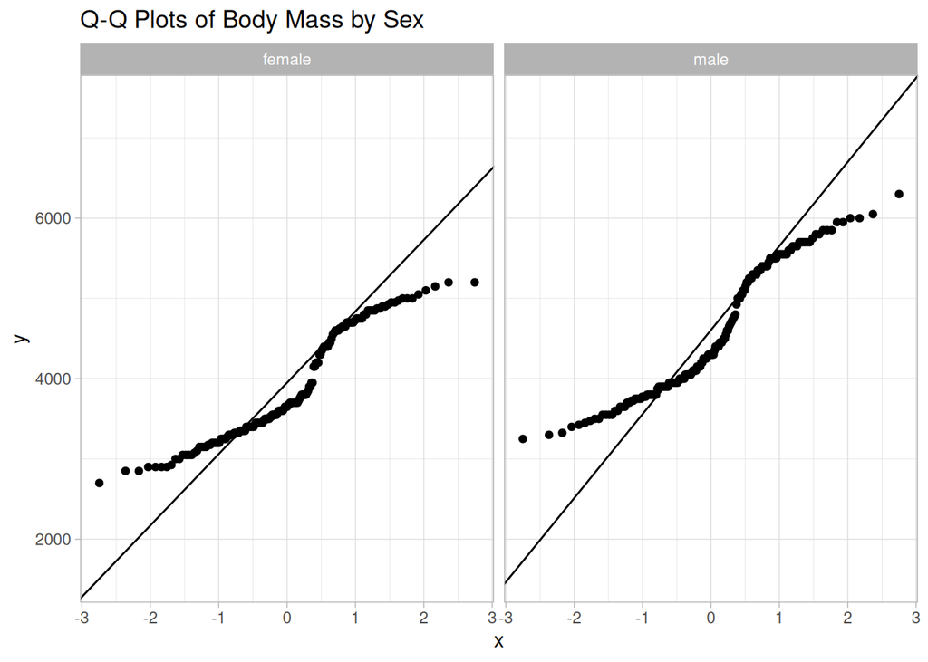

```r
# Visual check with QQ plots
dat.0 %>%
  ggplot(aes(sample = body_mass_g)) +
  stat_qq() +
  stat_qq_line() +
  facet_wrap(~sex) +
  theme_light() +
  labs(title = "Q-Q Plots of Body Mass by Sex")
```

```r
# Shapiro-Wilk Test
dat.0 %>%
  group_by(sex) %>%
  summarise(shapiro_p = shapiro.test(body_mass_g)$p.value)
```

```
## # A tibble: 2 × 2
##   sex       shapiro_p
##   <fct>         <dbl>
## 1 female 0.0000000616
## 2 male   0.000000123
```

## 4.2 Assumption 2 & Results

**Assumption: Homogeneity of Variance (Homoscedasticity).** Variances should be equal.

```r
# Levene's Test (using car package or var.test for simple 2-group F-test if normal)
var.test(body_mass_g ~ sex, data = dat.0)
```

```
##
##  F test to compare two variances
##
## data:  body_mass_g by sex
## F = 0.71537, num df = 164, denom df = 167, p-value = 0.03198
## alternative hypothesis: true ratio of variances is not equal to 1
## 95 percent confidence interval:
##  0.5270220 0.9714417
## sample estimates:
## ratio of variances
##          0.7153681
```

*Result:* If p < 0.05, variances are significantly different. We should use Welch’s t-test (which does not assume equal variance).

**Effect Size (Cohen’s d):**

Beyond p-values, we want to know the *magnitude* of the difference.

```r
# Manual calculation of Cohen's d for independent samples with unequal variance
# (Or strictly speaking, Glass's delta or Hedges' g might be preferred, but d is standard)
m_stats <- dat.0 %>% group_by(sex) %>% summarise(mean=mean(body_mass_g), sd=sd(body_mass_g), n=n())
print(m_stats)
```

```
## # A tibble: 2 × 4
##   sex     mean    sd     n
##   <fct>  <dbl> <dbl> <int>
## 1 female 3862.  666.   165
## 2 male   4546.  788.   168
```

```r
male_m <- m_stats$mean[m_stats$sex=="male"]
female_m <- m_stats$mean[m_stats$sex=="female"]
pooled_sd <- sqrt(((m_stats$n[1]-1)*m_stats$sd[1]^2 + (m_stats$n[2]-1)*m_stats$sd[2]^2) / (sum(m_stats$n)-2))

d_val <- (male_m - female_m) / pooled_sd
cat("Cohen's d:", round(d_val, 2))
```

```
## Cohen's d: 0.94
```

*Interpretation:* A Cohen’s d of 0.94 represents a **large** effect size (typically d > 0.8 is large).

**Final Test (Welch’s t-test):**

```r
t_result <- t.test(body_mass_g ~ sex, data = dat.0, var.equal = FALSE)
t_result
```

```
##
##  Welch Two Sample t-test
##
## data:  body_mass_g by sex
## t = -8.5545, df = 323.9, p-value = 4.794e-16
## alternative hypothesis: true difference in means between group female and group male is not equal to 0
## 95 percent confidence interval:
##  -840.5783 -526.2453
## sample estimates:
## mean in group female   mean in group male
##             3862.273             4545.685
```

## 4.3 ANOVA (One-way Analysis of Variance)

**Question:** Is there a significant difference in **Body Mass** between the three **Species**?

- $H_0: \mu_{Adelie} = \mu_{Chinstrap} = \mu_{Gentoo}$
- $H_1$: At least one species mean is different.

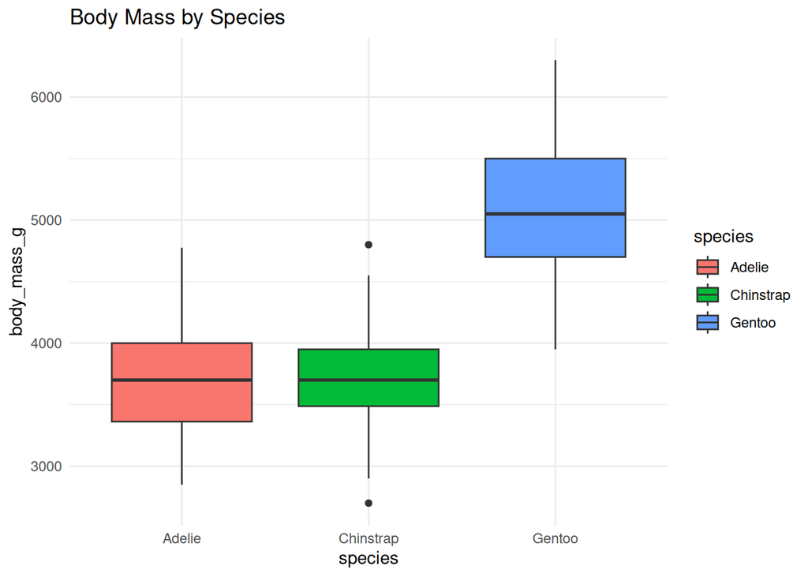

```r
# 1. Visualize
ggplot(dat.0, aes(x = species, y = body_mass_g, fill = species)) +
  geom_boxplot() +
  labs(title = "Body Mass by Species") +
  theme_minimal()
```

```r
# 2. Run ANOVA
# We use aov() which assumes equal variance.
# (For unequal variance, we'd use oneway.test)
aov_res <- aov(body_mass_g ~ species, data = dat.0)
summary(aov_res)
```

```
##              Df    Sum Sq  Mean Sq F value Pr(>F)
## species       2 145190219 72595110   341.9 <2e-16 ***
## Residuals   330  70069447   212332
## ---
## Signif. codes:  0 '***' 0.001 '**' 0.01 '*' 0.05 '.' 0.1 ' ' 1
```

*Result:* The p-value is extremely small (< 2e-16), so we reject $H_0$.

**Post-hoc Test (Tukey HSD):** Which specific pairs are different?

```r
TukeyHSD(aov_res)
```

```
##   Tukey multiple comparisons of means
##     95% family-wise confidence level
##
## Fit: aov(formula = body_mass_g ~ species, data = dat.0)
##
## $species
##                        diff       lwr       upr    p adj
## Chinstrap-Adelie   26.92385 -132.3528  186.2005 0.916431
## Gentoo-Adelie    1386.27259 1252.2897 1520.2554 0.000000
## Gentoo-Chinstrap 1359.34874 1194.4304 1524.2671 0.000000
```

# 5 Conclusion on the Data

This follows the frequentist framework of inference and hypothesis testing as outlined in the original lecture format.